# ICIS 2017 Recidivism Report

ASC

2023-04-21

### **Analysis 1**: Recidivism Rates by Offender Type, FY2017 Cohort

#### Figure 1

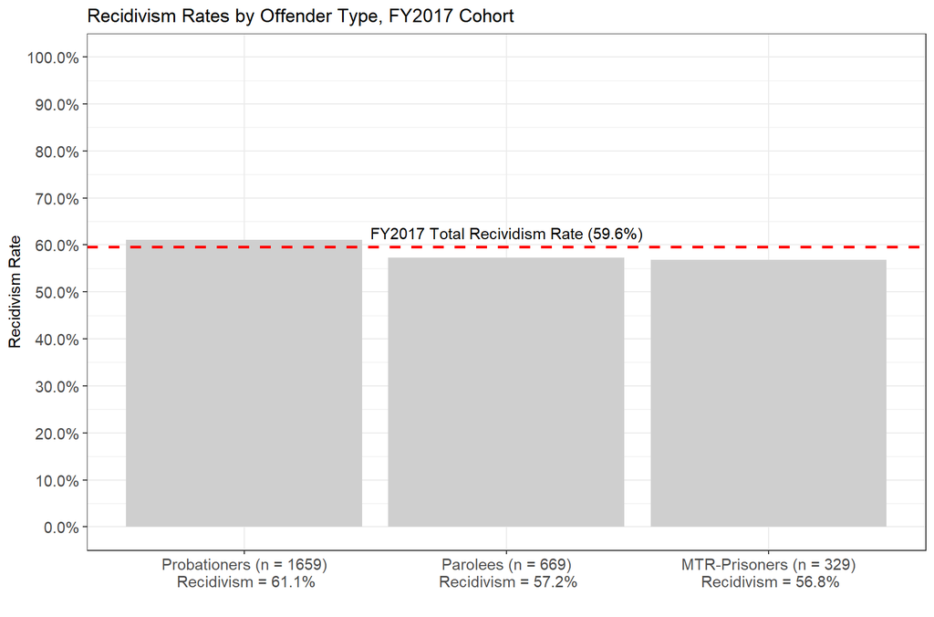

The difference in recidivism rates between offender types was not statistically significant, $\chi^2$(2, *N* = 2657) = 4.046, *p* = 0.132

#### Table 1

| Offender type | r | Sample size | Recidivism rate |
| --- | --- | --- | --- |
| Probationers | 1013 | 1659 | 61.1% |
| Parolees | 383 | 669 | 57.2% |
| MTR-Prisoners | 187 | 329 | 56.8% |
| Total | 1583 | 2657 | 59.6% |

### **Analysis 2**: Time-Period Recidivism Rates by Offender Type, FY2017 Cohort

#### Figure 2

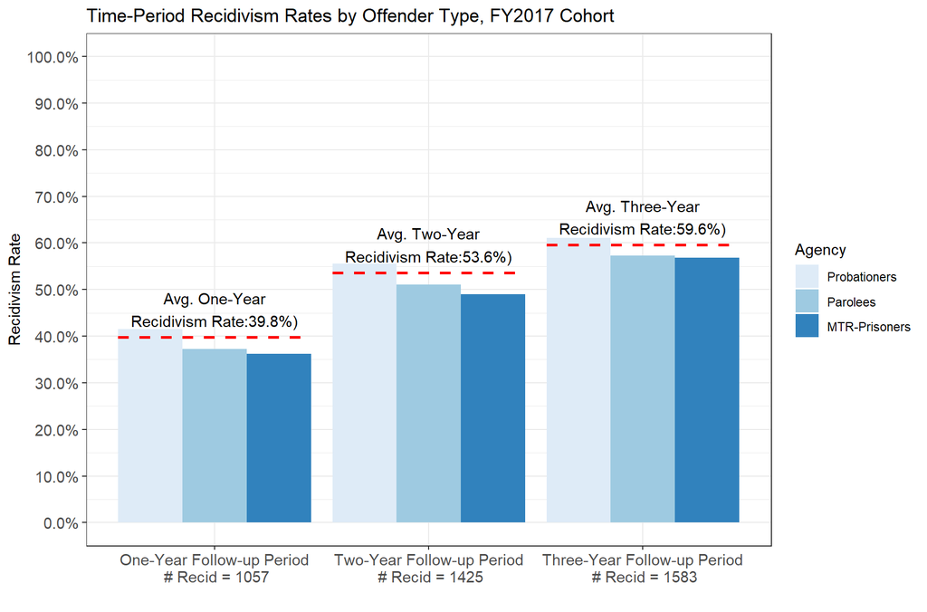

#### Table 2

| agency | 1-Year Follow-up Period | 2-Year Follow-up Period | 3-Year Follow-up Period |
| --- | --- | --- | --- |
| Probationers | 41.5% (r = 689, n = 1659) | 55.6% (r = 922, n = 1659) | 61.1% (r = 1013, n = 1659) |
| Parolees | 37.2% (r = 249, n = 669) | 51.1% (r = 342, n = 669) | 57.2% (r = 383, n = 669) |
| MTR-Prisoners | 36.2% (r = 119, n = 329) | 48.9% (r = 161, n = 329) | 56.8% (r = 187, n = 329) |
| Total | 39.8% (r = 1057, n = 2657) | 53.6% (r = 1425, n = 2657) | 59.6% (r = 1583, n = 2657) |

#### Table 2 a

Time-period

Recidivists

Percent

Cumulative percent

< 12 months

1057

39.8%

39.8%

12-24 months

368

13.9%

53.6%

24-36 months

158

5.9%

59.6%

Total

1583

### **Analysis 3**: Recidivism Rates for Probationers and Parolees, FYs 2005 - 2017 Cohorts

#### Figure 3

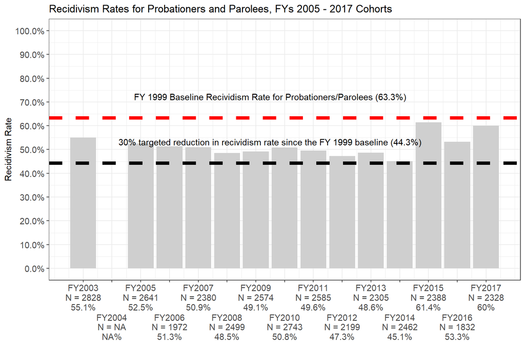

#### Table 3

| agency | recid_rate | year | n |
| --- | --- | --- | --- |
| Probation/Parole | 55.1 | 2003 | 2828 |
| Probation/Parole | NA | 2004 | NA |
| Probation/Parole | 52.5 | 2005 | 2641 |
| Probation/Parole | 51.3 | 2006 | 1972 |
| Probation/Parole | 50.9 | 2007 | 2380 |
| Probation/Parole | 48.5 | 2008 | 2499 |
| Probation/Parole | 49.1 | 2009 | 2574 |
| Probation/Parole | 50.8 | 2010 | 2743 |
| Probation/Parole | 49.6 | 2011 | 2585 |
| Probation/Parole | 47.3 | 2012 | 2199 |
| Probation/Parole | 48.6 | 2013 | 2305 |
| Probation/Parole | 45.1 | 2014 | 2462 |
| Probation/Parole | 61.4 | 2015 | 2388 |
| Probation/Parole | 53.3 | 2016 | 1832 |
| Probation/Parole | 60.0 | 2017 | 2328 |

### **Analysis 4**: Recidivism Rates for Probationers, FYs 2005 - 2017 Cohorts

#### Figure 4

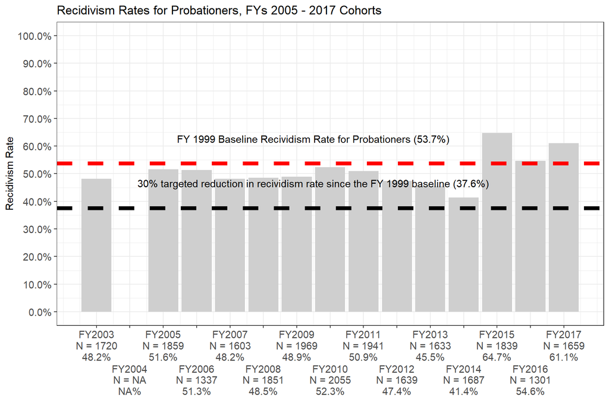

#### Table 4

| agency | recid_rate | year | n |
| --- | --- | --- | --- |
| Probationers | 48.2 | 2003 | 1720 |
| Probationers | NA | 2004 | NA |
| Probationers | 51.6 | 2005 | 1859 |
| Probationers | 51.3 | 2006 | 1337 |
| Probationers | 48.2 | 2007 | 1603 |
| Probationers | 48.5 | 2008 | 1851 |
| Probationers | 48.9 | 2009 | 1969 |
| Probationers | 52.3 | 2010 | 2055 |
| Probationers | 50.9 | 2011 | 1941 |
| Probationers | 47.4 | 2012 | 1639 |
| Probationers | 45.5 | 2013 | 1633 |
| Probationers | 41.4 | 2014 | 1687 |
| Probationers | 64.7 | 2015 | 1839 |
| Probationers | 54.6 | 2016 | 1301 |
| Probationers | 61.1 | 2017 | 1659 |

### **Analysis 5**: Recidivism Rates for Parolees, FYs 2005 - 2017 Cohorts

#### Figure 5

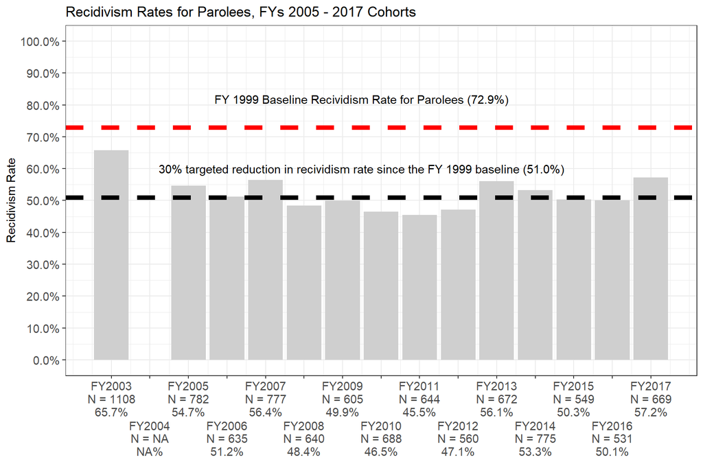

#### Table 5

| agency | recid_rate | year | n |
| --- | --- | --- | --- |
| Parolees | 65.7 | 2003 | 1108 |
| Parolees | NA | 2004 | NA |
| Parolees | 54.7 | 2005 | 782 |
| Parolees | 51.2 | 2006 | 635 |
| Parolees | 56.4 | 2007 | 777 |
| Parolees | 48.4 | 2008 | 640 |
| Parolees | 49.9 | 2009 | 605 |
| Parolees | 46.5 | 2010 | 688 |
| Parolees | 45.5 | 2011 | 644 |
| Parolees | 47.1 | 2012 | 560 |
| Parolees | 56.1 | 2013 | 672 |
| Parolees | 53.3 | 2014 | 775 |
| Parolees | 50.3 | 2015 | 549 |
| Parolees | 50.1 | 2016 | 531 |
| Parolees | 57.2 | 2017 | 669 |

### **Analysis 6**: Recidivism Rates for Maximum Term Released Prisoners, FYs 2005 - 2017 Cohorts

#### Figure 6

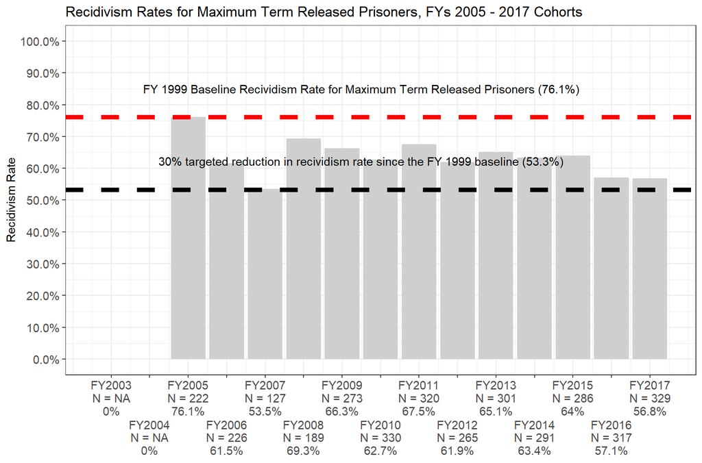

#### Table 6

| agency | recid_rate | year | n |
| --- | --- | --- | --- |
| Maximum-Term Released Prisoners | 0.0 | 2003 | NA |
| Maximum-Term Released Prisoners | 0.0 | 2004 | NA |
| Maximum-Term Released Prisoners | 76.1 | 2005 | 222 |
| Maximum-Term Released Prisoners | 61.5 | 2006 | 226 |
| Maximum-Term Released Prisoners | 53.5 | 2007 | 127 |
| Maximum-Term Released Prisoners | 69.3 | 2008 | 189 |
| Maximum-Term Released Prisoners | 66.3 | 2009 | 273 |
| Maximum-Term Released Prisoners | 62.7 | 2010 | 330 |
| Maximum-Term Released Prisoners | 67.5 | 2011 | 320 |
| Maximum-Term Released Prisoners | 61.9 | 2012 | 265 |
| Maximum-Term Released Prisoners | 65.1 | 2013 | 301 |
| Maximum-Term Released Prisoners | 63.4 | 2014 | 291 |
| Maximum-Term Released Prisoners | 64.0 | 2015 | 286 |
| Maximum-Term Released Prisoners | 57.1 | 2016 | 317 |
| Maximum-Term Released Prisoners | 56.8 | 2017 | 329 |

### **Analysis 7_8_9**: % of reoffenders by Agency and Disposition Status, FY2017 Cohort

#### Figure 7_8_9

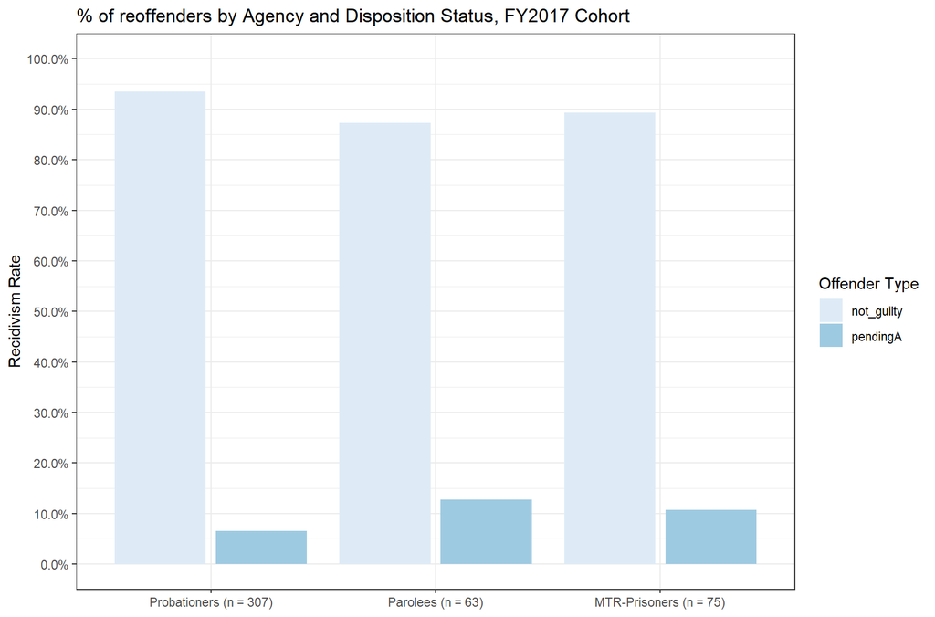

### **Analysis 10**: Recidivism Rates by Offender Type and Recidivism Type, FY2017 Cohort

#### Figure 10

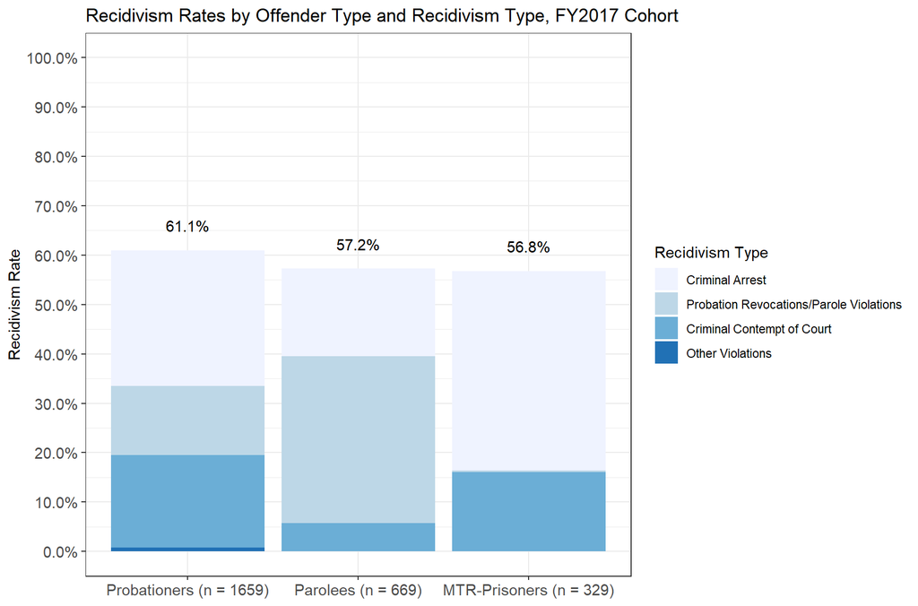

There was a statistically significant difference in criminal arrests between offender types, $\chi^2$(2, *N* = 2657) = 81.634, *p* < .001

There was a statistically significant difference in probation revocations/parole violations between offender types, $\chi^2$(2, *N* = 2657) = 259.405, *p* < .001

There was a statistically significant difference in criminal contempt of court between offender types, $\chi^2$(2, *N* = 2657) = 63.857, *p* < .001

#### Table 10

| ICIS_arrest | Probationers | Parolees | MTR-Prisoners |
| --- | --- | --- | --- |
| Criminal Arrest | 27.5% (r = 457) | 17.8% (r = 119) | 40.4% (r = 133) |
| Probation Revocations/Parole Violations | 14.0% (r = 232) | 33.8% (r = 226) | 0.3% (r = 1) |
| Criminal Contempt of Court | 18.7% (r = 310) | 5.7% (r = 38) | 16.1% (r = 53) |
| Other Violations | 0.8% (r = 14) | 0.0% (r = 0) | 0.0% (r = 0) |
| Total | 61.1% (r = 1013) | 57.2% (r = 383) | 56.8% (r = 187) |

#### Table 10 a

| Recidivism type | r | sample_size | Recidivism.rate |
| --- | --- | --- | --- |
| Criminal Arrest | 709 | 2657 | 26.7% |
| Probation Revocations/Parole Violations | 459 | 2657 | 17.3% |
| Criminal Contempt of Court | 401 | 2657 | 15.1% |
| Other Violations | 14 | 2657 | 0.5% |

### **Analysis 11**: Recidivism Rates by Offender Type and County, FY2017 Cohort

#### Figure 11

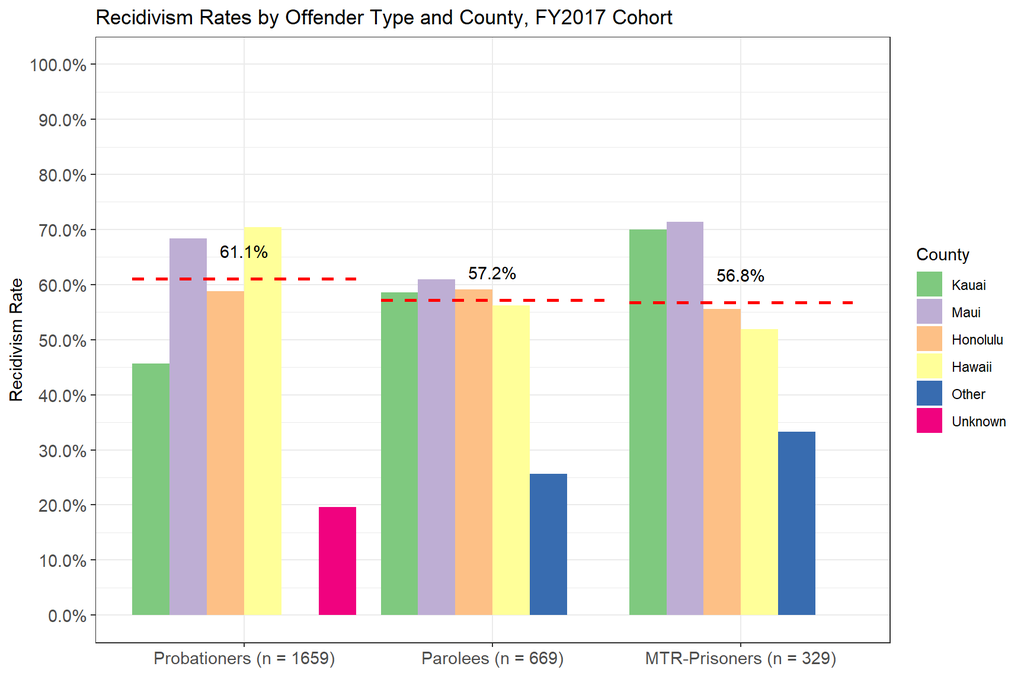

There was a statistically significant difference in overall recidivism rates between counties, $\chi^2$(5, *N* = 2657) = 77.024, *p* < .001

There was a statistically significant difference in recidivism rates between counties for probationers, $\chi^2$(4, *N* = 1659) = 67.727, *p* < .001

There was a statistically significant difference in recidivism rates between counties for parolees, $\chi^2$(4, *N* = 669) = 15.381, *p* = 0.00397

The difference in recidivism rates between counties for MTR-prisoners was not statistically significant, $\chi^2$(4, *N* = 329) = 4.26, *p* = 0.372

#### Table 11

| county | Probationers | Parolees | MTR-Prisoners |
| --- | --- | --- | --- |
| Kauai (N = 133) | 45.7% (r = 43, n = 94) | 58.6% (r = 17, n = 29) | 70.0% (r = 7, n = 10) |
| Maui (N = 404) | 68.4% (r = 201, n = 294) | 61.0% (r = 50, n = 82) | 71.4% (r = 20, n = 28) |
| Honolulu (N = 1570) | 58.8% (r = 505, n = 859) | 59.1% (r = 266, n = 450) | 55.6% (r = 145, n = 261) |
| Hawaii (N = 461) | 70.4% (r = 254, n = 361) | 56.2% (r = 41, n = 73) | 51.9% (r = 14, n = 27) |
| Other (N = 38) | NA (r = 0, n = 0) | 25.7% (r = 9, n = 35) | 33.3% (r = 1, n = 3) |
| Unknown (N = 51) | 19.6% (r = 10, n = 51) | NA (r = 0, n = 0) | NA (r = 0, n = 0) |
| Total (N = 2657) | 61.1% (r = 1013, n = 1659) | 57.2% (r = 383, n = 669) | 56.8% (r = 187, n = 329) |

#### Table 11 a

| county | r | sample_size | recidivism_rate |
| --- | --- | --- | --- |
| Kauai | 67 | 133 | 50.4% |
| Maui | 271 | 404 | 67.1% |
| Honolulu | 916 | 1570 | 58.3% |
| Hawaii | 309 | 461 | 67.0% |
| Other | 10 | 38 | 26.3% |
| Unknown | 10 | 51 | 19.6% |
| Total | 1583 | 2657 | 59.6% |

### **Analysis 12**: Recidivism Rates for Probationers by County and Recidivism Type, FY2017 Cohort

#### Figure 12

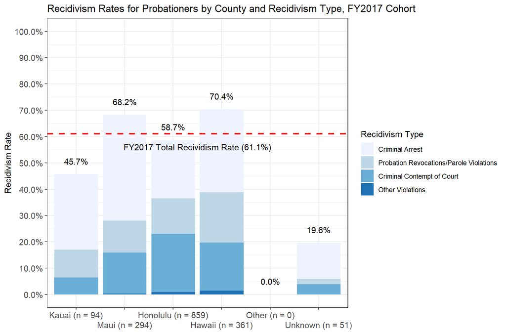

There was a statistically significant difference in recidivism rates between counties and types of recidivism for probationers, $\chi^2$(12, *N* = 1659) = 44.202, *p* < .001

There was a statistically significant difference in overall recidivism rates between counties for probationers, $\chi^2$(4, *N* = 1659) = 67.727, *p* < .001

There was a statistically significant difference in criminal arrests between counties for probationers, $\chi^2$(4, *N* = 1659) = 33.776, *p* < .001

The difference in probation revocations between counties for probationers was not statistically significant, $\chi^2$(4, *N* = 1659) = 6.398, *p* = 0.171

There was a statistically significant difference in criminal contempt of court between counties for probationers, $\chi^2$(4, *N* = 1659) = 26.051, *p* < .001

The difference in other violations between counties for probationers was not statistically significant, $\chi^2$(4, *N* = 1659) = 2.689, *p* = 0.611

#### Table 12

| ICIS_arrest | Kauai | Maui | Honolulu | Hawaii | Other | Unknown |
| --- | --- | --- | --- | --- | --- | --- |
| Criminal Arrest (R = 457, N = 1659) | 28.7% (r = 27, n = 94) | 40.1% (r = 118, n = 294) | 22.2% (r = 191, n = 859) | 31.6% (r = 114, n = 361) | NA (r = 0, n = 0) | 13.7% (r = 7, n = 51) |
| Probation Revocations/Parole Violations (R = 232, N = 1659) | 10.6% (r = 10, n = 94) | 12.2% (r = 36, n = 294) | 13.5% (r = 116, n = 859) | 19.1% (r = 69, n = 361) | NA (r = 0, n = 0) | 2.0% (r = 1, n = 51) |
| Criminal Contempt of Court (R = 310, N = 1659) | 6.4% (r = 6, n = 94) | 15.6% (r = 46, n = 294) | 22.1% (r = 190, n = 859) | 18.3% (r = 66, n = 361) | NA (r = 0, n = 0) | 3.9% (r = 2, n = 51) |
| Other Violations (R = 14, N = 1659) | 0.0% (r = 0, n = 94) | 0.3% (r = 1, n = 294) | 0.9% (r = 8, n = 859) | 1.4% (r = 5, n = 361) | NA (r = 0, n = 0) | 0.0% (r = 0, n = 51) |
| Total (R = 1013, N = 1659) | 45.7% (r = 43, n = 94) | 68.4% (r = 201, n = 294) | 58.8% (r = 505, n = 859) | 70.4% (r = 254, n = 361) | NA (r = 0, n = 0) | 19.6% (r = 10, n = 51) |

#### Table 12 a

| ICIS_arrest | r | sample_size | recidivism_rate | recidivism_rate_pretty |
| --- | --- | --- | --- | --- |
| Criminal Arrest | 457 | 1659 | 0.275 | 27.5% |
| Probation Revocations/Parole Violations | 232 | 1659 | 0.140 | 14.0% |
| Criminal Contempt of Court | 310 | 1659 | 0.187 | 18.7% |
| Other Violations | 14 | 1659 | 0.008 | 0.8% |

### **Analysis 13**: Recidivism Rates for Parolees by County and Recidivism Type, FY2017 Cohort

#### Figure 13

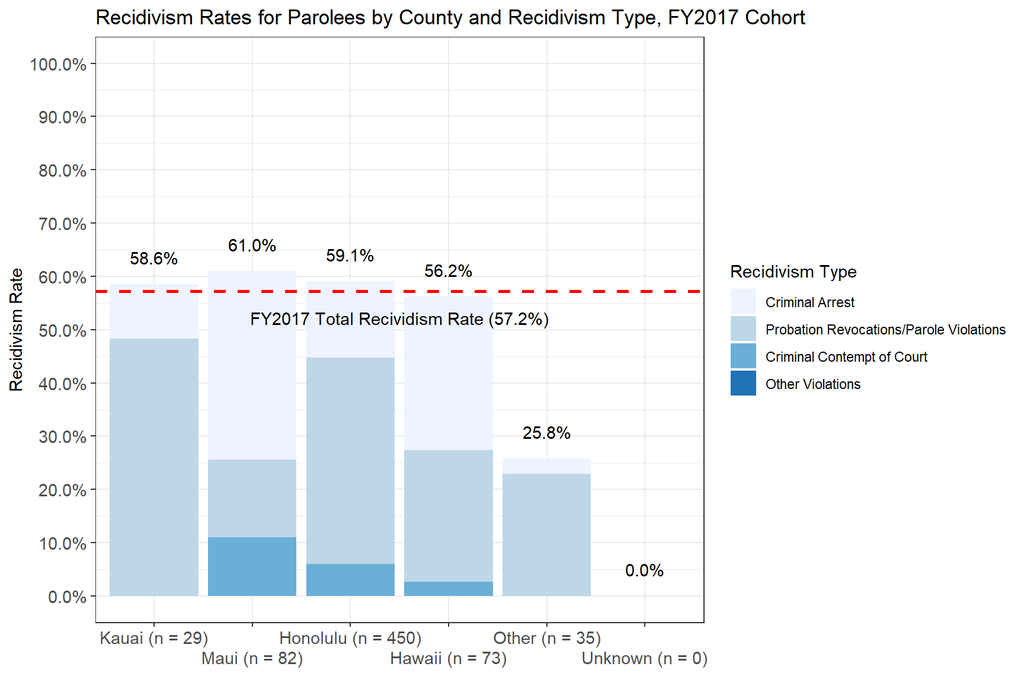

There was a statistically significant difference in recidivism rates between counties and types of recidivism for parolees, $\chi^2$(8, *N* = 669) = 46.621, *p* < .001

There was a statistically significant difference in overall recidivism rates between counties for parolees, $\chi^2$(4, *N* = 669) = 15.381, *p* = 0.00397

There was a statistically significant difference in criminal arrests between counties for parolees, $\chi^2$(4, *N* = 669) = 33.274, *p* < .001

There was a statistically significant difference in parole violations between counties for parolees, $\chi^2$(4, *N* = 669) = 40.866, *p* < .001

The difference in criminal contempt of court between counties for parolees was not statistically significant, $\chi^2$(4, *N* = 669) = 7.697, *p* = 0.103

#### Table 13

| ICIS_arrest | Kauai | Maui | Honolulu | Hawaii | Other | Unknown |
| --- | --- | --- | --- | --- | --- | --- |
| Criminal Arrest (r = 119, n = 669) | 10.3% (r = 3, n = 29) | 35.4% (r = 29, n = 82) | 14.4% (r = 65, n = 450) | 28.8% (r = 21, n = 73) | 2.9% (r = 1, n = 35) | NA (r = 0, n = 0) |
| Probation Revocations/Parole Violations (r = 226, n = 669) | 48.3% (r = 14, n = 29) | 14.6% (r = 12, n = 82) | 38.7% (r = 174, n = 450) | 24.7% (r = 18, n = 73) | 22.9% (r = 8, n = 35) | NA (r = 0, n = 0) |
| Criminal Contempt of Court (r = 38, n = 669) | 0.0% (r = 0, n = 29) | 11.0% (r = 9, n = 82) | 6.0% (r = 27, n = 450) | 2.7% (r = 2, n = 73) | 0.0% (r = 0, n = 35) | NA (r = 0, n = 0) |
| Other Violations (r = 0, n = 669) | 0.0% (r = 0, n = 29) | 0.0% (r = 0, n = 82) | 0.0% (r = 0, n = 450) | 0.0% (r = 0, n = 73) | 0.0% (r = 0, n = 35) | NA (r = 0, n = 0) |

#### Table 13 a

| ICIS_arrest | r_icis_arrest | n_icis_arrest | recidivism_rate | recidivism_rate_pretty |
| --- | --- | --- | --- | --- |
| Criminal Arrest | 119 | 669 | 0.178 | 17.8% |
| Probation Revocations/Parole Violations | 226 | 669 | 0.338 | 33.8% |
| Criminal Contempt of Court | 38 | 669 | 0.057 | 5.7% |
| Other Violations | 0 | 669 | 0.000 | 0.0% |

### **Analysis 14**: Average Time to Recidivism by Offender Type and Recidivism Type, FY2017 Cohort

#### Figure 14

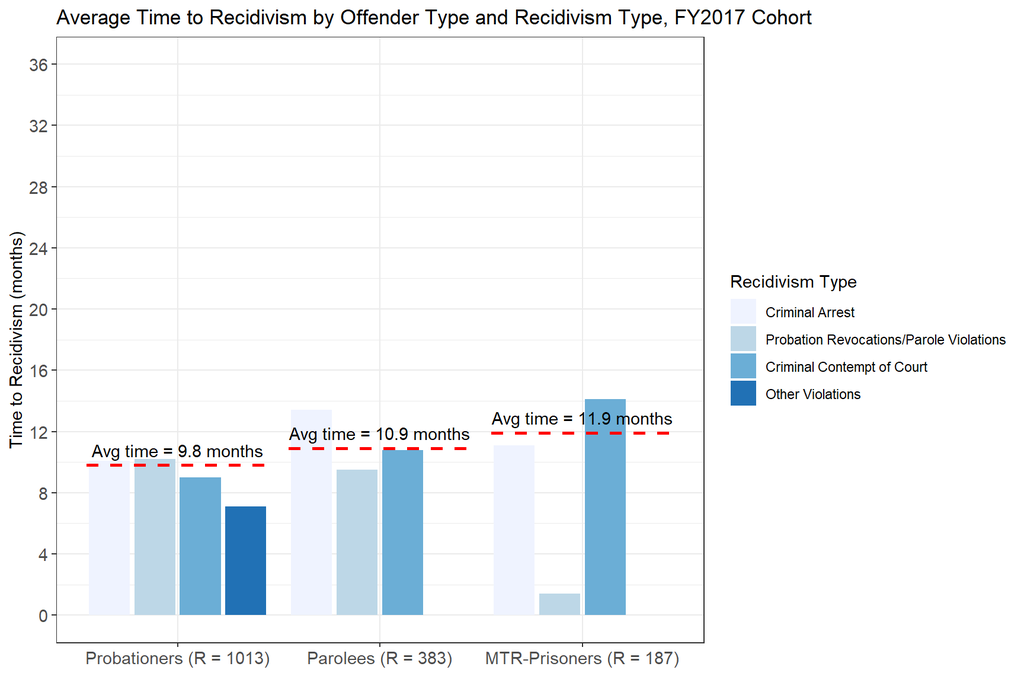

Criminal Arrest: The main effect of agency is statistically significant and small (F(2, 706) = 5.73, p = 0.003; Eta2 = 0.02, 95% CI [3.22e-03, 1.00])

Probation Revocations/Parole Violations: The main effect of agency is statistically not significant and very small (F(2, 456) = 0.86, p = 0.423; Eta2 = 3.77e-03, 95% CI [0.00, 1.00])

Criminal Contempt of Court: The main effect of agency is statistically significant and small (F(2, 398) = 8.50, p < .001; Eta2 = 0.04, 95% CI [0.01, 1.00])

#### Table 14

| ICIS_arrest | Probationers | Parolees | MTR-Prisoners |
| --- | --- | --- | --- |
| Criminal Arrest | 10.1 (r = 457) | 13.4 (r = 119) | 11.1 (r = 133) |
| Probation Revocations/Parole Violations | 10.2 (r = 232) | 9.5 (r = 226) | 1.4 (r = 1) |
| Criminal Contempt of Court | 9 (r = 310) | 10.8 (r = 38) | 14.1 (r = 53) |
| Other Violations | 7.1 (r = 14) | NA (r = 0) | NA (r = 0) |

#### Table 14 a

| ICIS_arrest | r_recid_type | avg_months_recidivate |
| --- | --- | --- |
| Criminal Arrest | 709 | 10.9 |
| Probation Revocations/Parole Violations | 459 | 9.9 |
| Criminal Contempt of Court | 401 | 9.8 |
| Other Violations | 14 | 7.1 |

### **Analysis 15**: Average Time to Recidivism by County and Recidivism Type, FY2017 Cohort

#### Figure 15

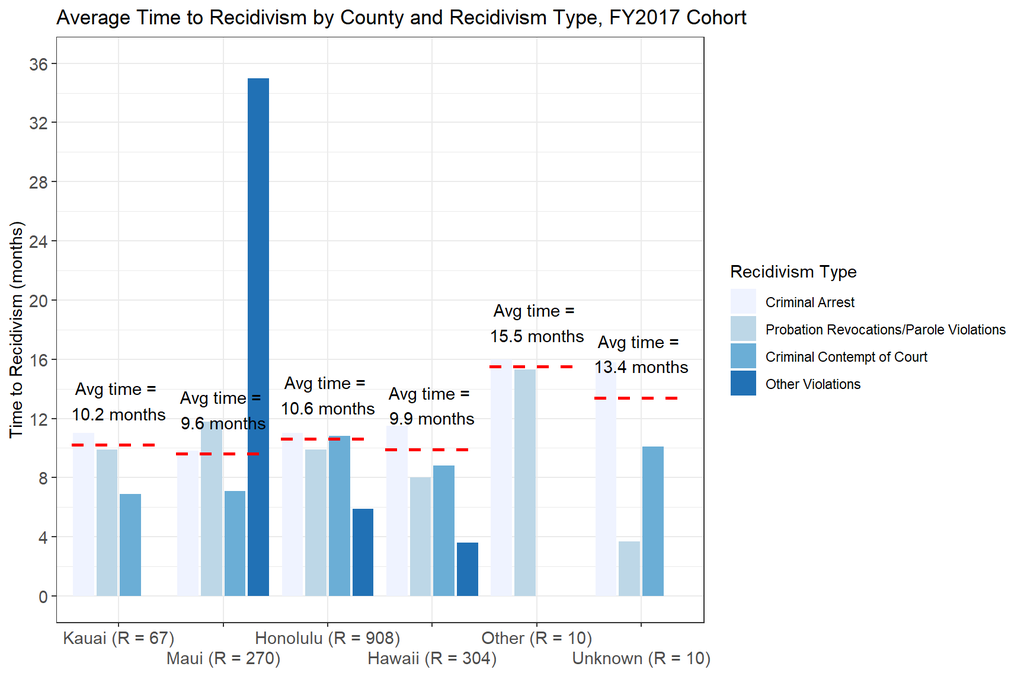

Criminal Arrest: The main effect of county is statistically not significant and very small (F(5, 703) = 1.09, p = 0.363; Eta2 = 7.71e-03, 95% CI [0.00, 1.00])

Probation Revocations/Parole Violations: The main effect of county is statistically significant and small (F(5, 453) = 2.23, p = 0.050; Eta2 = 0.02, 95% CI [4.73e-06, 1.00])

Criminal Contempt of Court: The main effect of county is statistically significant and small (F(4, 396) = 2.63, p = 0.034; Eta2 = 0.03, 95% CI [1.02e-03, 1.00])

#### Table 15

| ICIS_arrest | Kauai | Maui | Honolulu | Hawaii | Other | Unknown |
| --- | --- | --- | --- | --- | --- | --- |
| Criminal Arrest | 11 (r = 37) | 9.8 (r = 163) | 11 (r = 353) | 11.5 (r = 147) | 16 (r = 2) | 15.8 (r = 7) |
| Probation Revocations/Parole Violations | 9.9 (r = 24) | 11.8 (r = 48) | 9.9 (r = 291) | 8 (r = 87) | 15.3 (r = 8) | 3.7 (r = 1) |
| Criminal Contempt of Court | 6.9 (r = 6) | 7.1 (r = 59) | 10.8 (r = 264) | 8.8 (r = 70) | NA (r = 0) | 10.1 (r = 2) |
| Other Violations | NA (r = 0) | 35 (r = 1) | 5.9 (r = 8) | 3.6 (r = 5) | NA (r = 0) | NA (r = 0) |

#### Table 15 a

| ICIS_arrest | r_recidivism_type | avg_months_recidivate |
| --- | --- | --- |
| Criminal Arrest | 709 | 10.9 |
| Probation Revocations/Parole Violations | 459 | 9.9 |
| Criminal Contempt of Court | 401 | 9.8 |
| Other Violations | 14 | 7.1 |

### **Analysis 16**: Recidivism Rates by Initial Offense Type, FY2017 Cohort

#### Figure 16

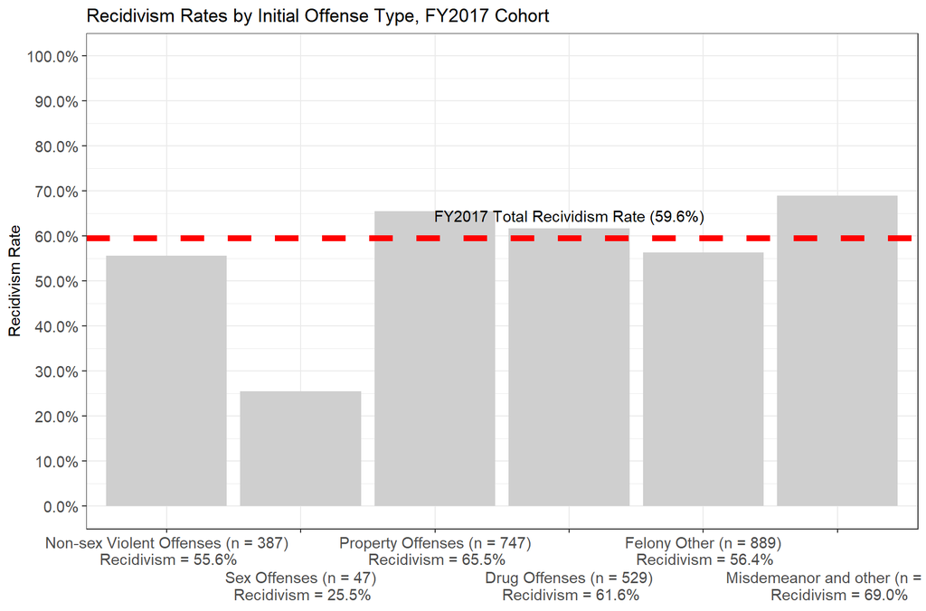

There was a statistically significant difference in recidivism rates between initial offense types, $\chi^2$(5, *N* = 2657) = 42.837, *p* < .001

#### Table 16

| initial_offense_category | r | sample_size | prop_recidivate_pretty |
| --- | --- | --- | --- |
| Non-sex Violent Offenses | 215 | 387 | 55.6% |
| Sex Offenses | 12 | 47 | 25.5% |
| Property Offenses | 489 | 747 | 65.5% |
| Drug Offenses | 326 | 529 | 61.6% |
| Felony Other | 501 | 889 | 56.4% |
| Misdemeanor and other | 40 | 58 | 69.0% |

### **Analysis 17**: Recidivism Rates by Initial Offense Type and Recidivism Type, FY2017 Cohort

#### Figure 17

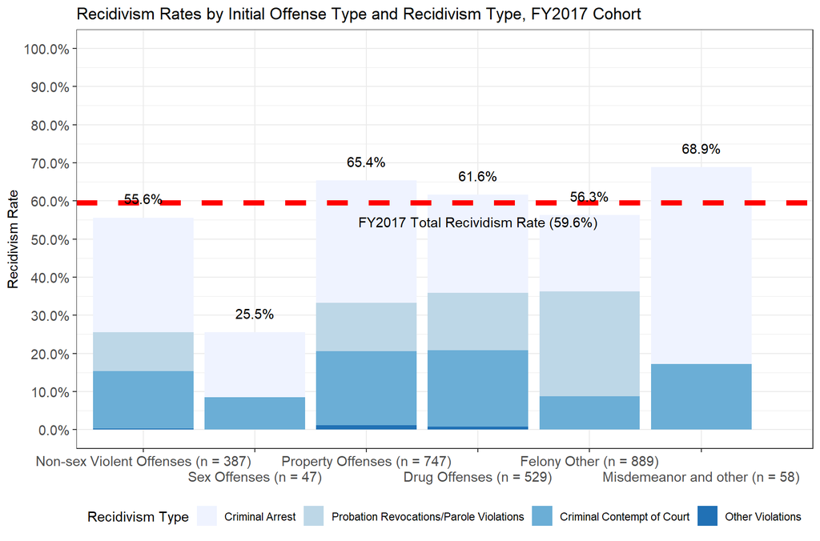

There was a statistically significant difference in criminal arrests between initial offense types, $\chi^2$(5, *N* = 2657) = 45.905, *p* < .001

There was a statistically significant difference in probation revocations/parole violations between initial offense types, $\chi^2$(5, *N* = 2657) = 151.905, *p* < .001

There was a statistically significant difference in criminal contempt of court between initial offense types, $\chi^2$(5, *N* = 2657) = 39.682, *p* < .001

#### Table 17

| ICIS_arrest | Non-sex Violent Offenses | Sex Offenses | Property Offenses | Drug Offenses | Felony Other | Misdemeanor and other |
| --- | --- | --- | --- | --- | --- | --- |
| Criminal Arrest | 30.0% (r = 116, n = 387) | 17.0% (r = 8, n = 47) | 32.1% (r = 240, n = 747) | 25.7% (r = 136, n = 529) | 20.1% (r = 179, n = 889) | 51.7% (r = 30, n = 58) |
| Probation Revocations/Parole Violations | 10.3% (r = 40, n = 387) | 0.0% (r = 0, n = 47) | 12.7% (r = 95, n = 747) | 15.1% (r = 80, n = 529) | 27.4% (r = 244, n = 889) | 0.0% (r = 0, n = 58) |
| Criminal Contempt of Court | 15.0% (r = 58, n = 387) | 8.5% (r = 4, n = 47) | 19.4% (r = 145, n = 747) | 20.0% (r = 106, n = 529) | 8.8% (r = 78, n = 889) | 17.2% (r = 10, n = 58) |
| Other Violations | 0.3% (r = 1, n = 387) | 0.0% (r = 0, n = 47) | 1.2% (r = 9, n = 747) | 0.8% (r = 4, n = 529) | 0.0% (r = 0, n = 889) | 0.0% (r = 0, n = 58) |

#### Table 17 a

| ICIS_arrest | r_icis_arrest | n_icis_arrest | recidivism_rate | recidivism_rate_pretty |
| --- | --- | --- | --- | --- |
| Criminal Arrest | 709 | 2657 | 0.267 | 26.7% |
| Probation Revocations/Parole Violations | 459 | 2657 | 0.173 | 17.3% |
| Criminal Contempt of Court | 401 | 2657 | 0.151 | 15.1% |
| Other Violations | 14 | 2657 | 0.005 | 0.5% |

### **Analysis 18**: Recidivism Rates by Offender Type and Sex, FY2017 Cohort

#### Figure 18

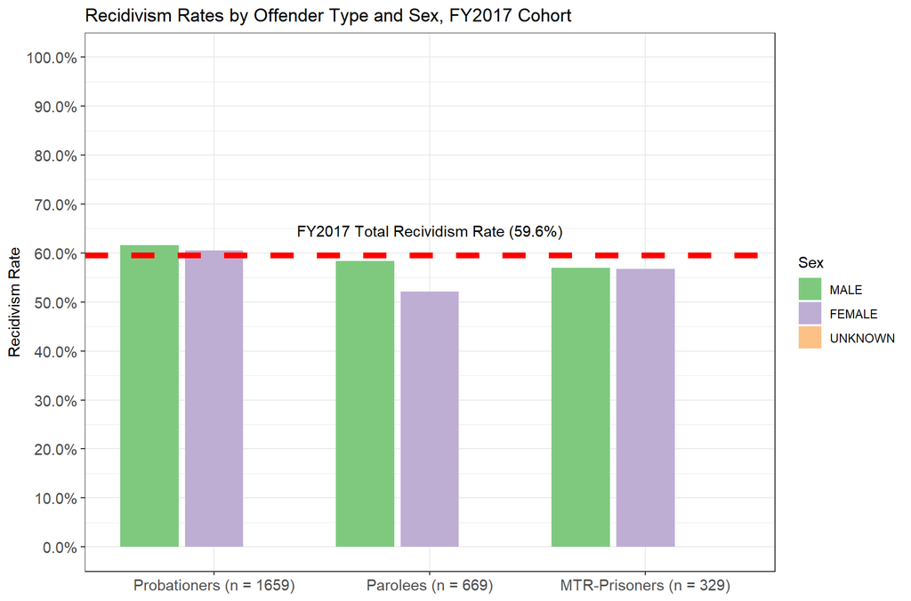

The difference in recidivism rates between male and female parolees was not statistically significant, $\chi^2$(1, *N* = 669) = 1.322, *p* = 0.25

The difference in recidivism rates between male and female MTR-prisoners was not statistically significant, $\chi^2$(2, *N* = 329) = 1.323, *p* = 0.516

#### Table 18

| SEX | Probationers | Parolees | MTR-Prisoners |
| --- | --- | --- | --- |
| MALE | 61.6% (r = 803, n = 1304) | 58.4% (r = 321, n = 550) | 57.0% (r = 170, n = 298) |
| FEMALE | 60.5% (r = 210, n = 347) | 52.1% (r = 62, n = 119) | 56.7% (r = 17, n = 30) |
| UNKNOWN | 0.0% (r = 0, n = 8) | NA (r = 0, n = 0) | 0.0% (r = 0, n = 1) |

#### Table 18 a

| SEX | r | sample_size | Recidivism Rate |
| --- | --- | --- | --- |
| MALE | 1294 | 2152 | 60.1% |
| FEMALE | 289 | 496 | 58.3% |
| UNKNOWN | 0 | 9 | 0.0% |

### **Analysis 19**: Recidivism Rates by Offender Type and Race, FY2017 Cohort

#### Figure 19

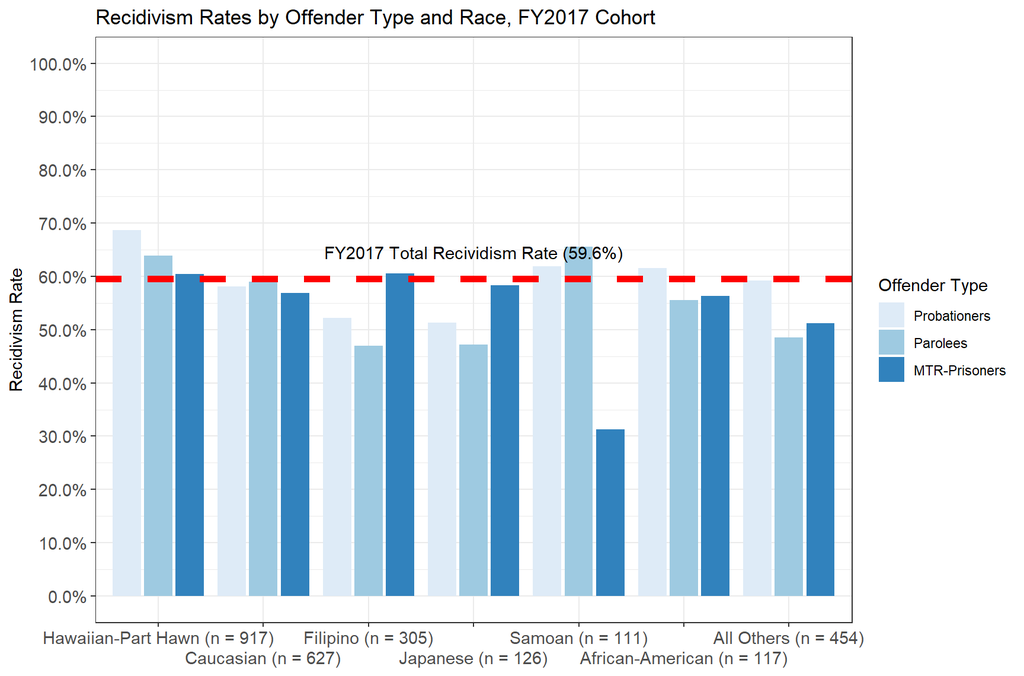

#### Table 19

| agency | Hawaiian-Part Hawn | Caucasian | Filipino | Japanese | Samoan | African-American | All Others |
| --- | --- | --- | --- | --- | --- | --- | --- |
| Probationers | 68.7% (r = 369, n = 537) | 58.1% (r = 243, n = 418) | 52.2% (r = 96, n = 184) | 51.3% (r = 40, n = 78) | 61.9% (r = 39, n = 63) | 61.5% (r = 40, n = 65) | 59.2% (r = 186, n = 314) |
| Parolees | 63.9% (r = 154, n = 241) | 59.0% (r = 85, n = 144) | 47.0% (r = 39, n = 83) | 47.2% (r = 17, n = 36) | 65.6% (r = 21, n = 32) | 55.6% (r = 20, n = 36) | 48.5% (r = 47, n = 97) |
| MTR-Prisoners | 60.4% (r = 84, n = 139) | 56.9% (r = 37, n = 65) | 60.5% (r = 23, n = 38) | 58.3% (r = 7, n = 12) | 31.3% (r = 5, n = 16) | 56.3% (r = 9, n = 16) | 51.2% (r = 22, n = 43) |

#### Table 19 a

| Ethnicity | r | sample_size | Recidivism Rate |
| --- | --- | --- | --- |
| Hawaiian-Part Hawn | 607 | 917 | 66.2% |
| Caucasian | 365 | 627 | 58.2% |
| Filipino | 158 | 305 | 51.8% |
| Japanese | 64 | 126 | 50.8% |
| Samoan | 65 | 111 | 58.6% |
| African-American | 69 | 117 | 59.0% |
| All Others | 255 | 454 | 56.2% |

### **Analysis 20**: Recidivism Rates by Offender Type and Age Range, FY2017 Cohort

#### Figure 20

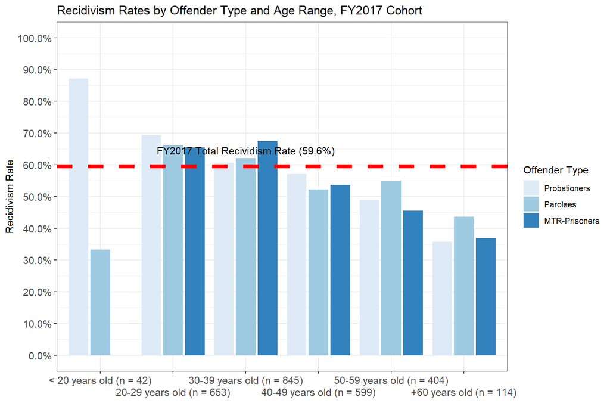

The difference in recidivism rates between age groups among parolees was not statistically significant, $\chi^2$(5, *N* = 669) = 10.525, *p* = 0.0617

There was a statistically significant difference in recidivism rates between age groups among MTR-prisoners, $\chi^2$(4, *N* = 329) = 12.837, *p* = 0.0121

There was a statistically significant difference in recidivism rates between age groups among all ofenders, $\chi^2$(5, *N* = 2657) = 73.322, *p* < .001

#### Table 20

| agency | < 20 years old | 20-29 years old | 30-39 years old | 40-49 years old | 50-59 years old | +60 years old |
| --- | --- | --- | --- | --- | --- | --- |
| Probationers | 87.2% (r = 34, n = 39) | 69.3% (r = 361, n = 521) | 60.7% (r = 316, n = 521) | 57.1% (r = 185, n = 324) | 49.0% (r = 97, n = 198) | 35.7% (r = 20, n = 56) |
| Parolees | 33.3% (r = 1, n = 3) | 66.2% (r = 51, n = 77) | 62.1% (r = 144, n = 232) | 52.2% (r = 93, n = 178) | 55.0% (r = 77, n = 140) | 43.6% (r = 17, n = 39) |
| MTR-Prisoners | NA (r = 0, n = 0) | 65.5% (r = 36, n = 55) | 67.4% (r = 62, n = 92) | 53.6% (r = 52, n = 97) | 45.5% (r = 30, n = 66) | 36.8% (r = 7, n = 19) |

#### Table 20 a

| age_range | r | sample_size | recidivism_rate |
| --- | --- | --- | --- |
| < 20 years old | 35 | 42 | 0.833 |
| 20-29 years old | 448 | 653 | 0.686 |
| 30-39 years old | 522 | 845 | 0.618 |
| 40-49 years old | 330 | 599 | 0.551 |
| 50-59 years old | 204 | 404 | 0.505 |
| +60 years old | 44 | 114 | 0.386 |

#### Figure 21

[figure not shown]

Among MTR-prisoners, the difference in recidivism rates between sentenced felons and parole violators was not statistically significant, $\chi^2$(1, *N* = 329) = 2.206, *p* = 0.138

#### Table 21

| Last Status | r | sample_size_psd | Recidivism Rate |
| --- | --- | --- | --- |
| Sentenced Felons | 139 | 233 | 59.7% |
| Parole Violators | 48 | 96 | 50.0% |